# Nancy: Transportation system

Moving around this small city

Nancy

going to France

Published

October 26, 2021

> **There is no special student ticket in Nancy**

# Transportation inside Nancy

## Walking

You may be surprised but, Nancy being a small city, walking is frequently the easiest way to get around, especially the city center and places around the IDMC.

Since the public transport systems shuts down around midnight, if you go out late you will find yourself walking a lot.

According to Google Maps, it takes 30 minutes to walk from one extreme of the city center to the other.

[interactive chart not shown]

## Bus and Tram

In Nancy there is only one tram line, the **T1**, and three main bus lines, **T2**, **T3**, and **T4**. The other bus lines are named using numbers.

[figure not shown]

You must buy a ticket **before** hoping on the bus, there are no vending machines inside the buses. **You have to validate when you enter the bus**.

Many bus stops, but not all of them, have vending machines for tickets.

The flat rate for a single trip is around **1.20 €**. Once validated, the same ticket can be used for up to one hour, meaning you can transfer as many times as you want within that hour without being charged extra.

There is also a ticket valid for 10 rides for about 11 €, I have found this ticket to be the most convenient for those living close to the center.

There are also subscription cards that can be bought at the *Gare* (Main station). Since I live close enough to the center, I have managed really well without a subscription card.

[figure not shown]

### Schedules

The tram and the buses in Nancy normally come every 10 minutes. Many bus stops, but not all of them, have a screen showing when the next bus is coming.

Google Maps works really well with the public transport in Nancy!

However, there are days when protests (*manifestations*) perturb the normal functioning of the public transport system. This is most common during the weekends.

[STAN](https://www.reseau-stan.com/telecharger-lapplication) is the official app of the public transport in Nancy, and it is updated with information about any detours or irregularities. Personally, I find it is not user friendly, and I have managed to live here without using it. The [STAN Twitter](https://twitter.com/reseaustan) is also useful.

### Free on weekends

> **On Saturday and Sunday, the local public transport system can be used for free!**

This is one of the coolest features in Nancy!

There are different schedules, though: - On Saturday, buses come every 20 minutes - On Sunday, buses come every 10 minutes

## Bike

### Bike infrastructure

Nancy has really good bike infrastructure, specially outside the center.

Close to the center, bikes are supposed to go along the traffic. There are signs showing where bikes are supposed to go:

[interactive chart not shown]

Outside the city center, it is more common to find special lanes for bikes, far away from car traffic.

[interactive chart not shown]

### Buying a bike

I bought my second-hand bike through the website [Leboncoin](https://www.leboncoin.fr/) (“the good corner”) for around 90 €.

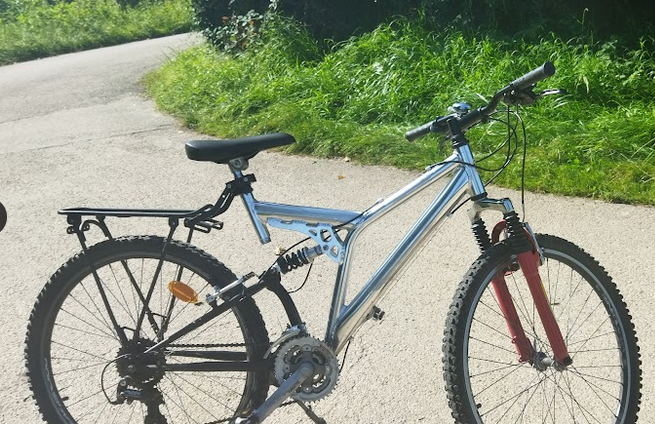

There is also the [Association Dynamo](https://atelierdynamo.fr/), a collective for the sustainable use of bikes. They have cheap second-hand and refourbished bikes.

[interactive chart not shown]

### Bike repair

The [Association Dynamo](https://atelierdynamo.fr/), just mentioned above, is a very good place for fixing your bike.

In their shop, you have to repair your bike yourself. They have every tool you could ever need, and there is always someone (normally another student) to guide you along the process. They also usually have at least one person that can speak English.

To get to use the shop, you have to subscribe for 17 € for a whole year (student price). It *is* a really good price! From my experience, fixing a bike in a private shop can easily start in 30 €, becoming more expensive really quickly.

[interactive chart not shown]

### Renting a bike

Nancy has [VéloStan](http://www.velostanlib.fr/), a bike rental service. To rent a bike you need to have a European bank account.

They only have stations around the center of the city, so they are not really usefull for exploring the city.

### Biking rules

As withh many rules in France, on the one hand there is what the law says, and on the other hand there is what people actually do in daily life.

The rules for biking within a city are - to always use a helmet - use a bright yellow vest at night (so that cars can see you) - drive only in bike lanes - only zones marked with ‘30 km/h’ can be used by bikes in any sense of traffic

But in reality, the French are more flexible, from what I’ve seen: - around half of bikers use helmets - only some bikers use yellow vests at night - bikers normally also use the sidewalks - bikers use any road in both senses of traffic

…and no one seems to bait an eye about that. Apparently, as long as you are not putting anyone else in danger and have some common sense about moving in traffic, people will tolerate bad biking.

# Traveling outside Nancy

Something cool and convenient about Europe, is that cities and countries are really close to each other.

## Regional trains

Almost surely the first place you knew in Nancy was the *Gare* (Main station). Trains to other parts of France and Europe depart from here.

Tickets can be bought in the [SNCF website](https://www.sncf-connect.com/), also available in English.

[interactive chart not shown]

The most common destinations are **Metz** (pronounced [[mɛs]](https://upload.wikimedia.org/wikipedia/commons/f/f2/Prononciationmetz.ogg)) and **Strassbourg**, the two biggest cities the closest to Nancy.

| City | Direct trip |
| --- | --- |
| Metz | 30 min |
| Strassboug | 1h 30 min |

### Discount Cards

Trains tickets can be expensive! It is recommended to get a discount card.

for example:

- [Carte Jeune](https://www.sncf-connect.com/app/catalogue/description/carte-avantage-jeune) or [Carte Adulte](https://www.sncf-connect.com/app/en-en/catalogue/description/carte-avantage-adulte), valid in all France.
- [Carte Primo](https://m.ter.sncf.com/grand-est/tarifs-cartes/cartes-reduction/carte-primo) ($<$ 26 years old), [Carte Presto](https://m.ter.sncf.com/grand-est/tarifs-cartes/cartes-reduction/carte-presto)($\geq$ 26 years old), [Carte Flue](https://m.ter.sncf.com/grand-est/tarifs-cartes/cartes-reduction/carte-fluo) (everyone). These are special offers only for the Grand-Est region, where Nancy is.

with a discount card, I am getting trips to Metz for around 4 € and to Strassbourg for around 7 €, a bargain!

## Bus

**Flixbus** and **BlaBla Bus** are bus companies with very cheap prices and decent service.

Their Nancy bus stop is close to the city center:

[interactive chart not shown]

Since Nancy is not that big, there are actually very few bus routes going through the city, and those that do pass by Nancy usually have very inconvenient times.

For many trips, it is usually easier to take a cheap train to Metz or Strassbourg, and then take a bus there.

## Airports

There is a Lorraine airport between Nancy and Metz, and to get there there are buses departing from the Nancy Gare. However, it is a small airport without that many good connections.

[interactive chart not shown]

Many students find it easier to take a train to Luxembourg and take a flight from there.

Since **Luxembourg** is also part of the [Schengen Area](https://en.wikipedia.org/wiki/Schengen_Area), where movement of people is free, it is really easy to cross the border back and forth (there are no controls).

Ryan Air, a low-budget airline, has many flights from Luxembourg!

[interactive chart not shown]

And that’s it!

[figure not shown]